# R Project 1

```r
ClevelandHD <- read.csv("C:/Users/saket/Downloads/ClevelandHD.csv")
HungaryHD <- read.csv("C:/Users/saket/Downloads/HungaryHD.csv")
```

# 1. How many of the 303 patients were diagnosed with heart disease?

```r
sum(ClevelandHD$presenceHD==1)
```

```
[1] 139
```

# 2. Make a histogram and a qqplot of the data in the “maxheartrate” column.

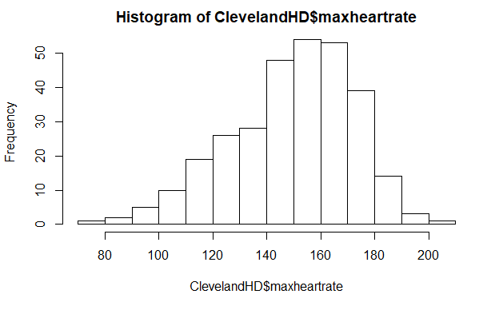

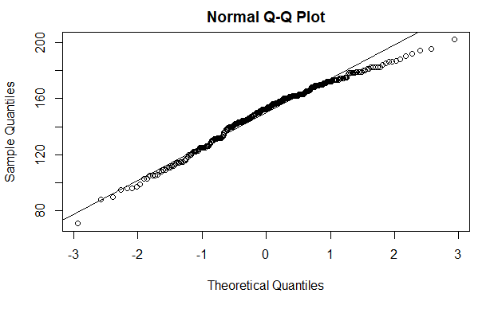

```r
qqnorm(ClevelandHD$maxheartrate)
qqline(ClevelandHD$maxheartrate)
```

# 3. For this column, report the sample mean, median, sample standard deviation, and 95% confidence interval for the population mean.

```r
mean(ClevelandHD$maxheartrate)
```

[output not shown]

```r
median(ClevelandHD$maxheartrate)
```

[output not shown]

```r
sd(ClevelandHD$maxheartrate)
```

[output not shown]

```r
t.test(ClevelandHD$maxheartrate)
```

```
    One Sample t-test

data:  ClevelandHD$maxheartrate
t = 113.84, df = 302, p-value < 2.2e-16
alternative hypothesis: true mean is not equal to 0
95 percent confidence interval:
 147.0212 152.1933
sample estimates:
mean of x
 149.6073
```

# 4. Make a side-by-side boxplot of the maximum heart rate for those patients diagnosed with heart disease vs. those patients not diagnosed with heart disease.

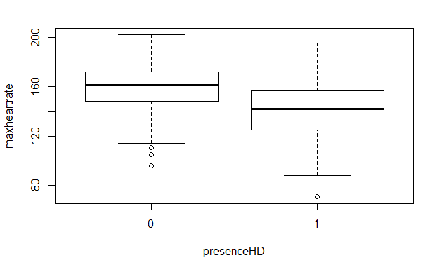

# 5. Do a t-test to test whether the maximum heart rate is significantly different for those patients diagnosed with heart disease vs. those patients not diagnosed with heart disease. Report both the p-value and the 95% confidence interval for the difference of the population means. Clearly state your conclusion.

```r
heart.data.withDisease <- ClevelandHD[ClevelandHD$presenceHD==1,]
heart.data.withoutDisease <- ClevelandHD[ClevelandHD$presenceHD==0,]
t.test(heart.data.withDisease$maxheartrate, heart.data.withoutDisease$maxheartrate)
```

```
    Welch Two Sample t-test

data:  heart.data.withDisease$maxheartrate and heart.data.withoutDisease$maxheartrate
t = -7.8579, df = 272.27, p-value = 9.106e-14
alternative hypothesis: true difference in means is not equal to 0
95 percent confidence interval:
 -23.90912 -14.32900
sample estimates:
mean of x mean of y
  139.259   158.378
```